# DSCI 522 Hypothesis Test

Katie Birchard, Ryan Homer, Andrea Lee

## Hypothesis Test: What is the strongest predictor of avocado prices in the United States?

To conduct a hypothesis test, we will fit an additive linear model and interpret the p-values to determine which features are significant.

The features we will be testing are:

- `total_volume`: total volume of avocados sold
- `PLU_4046`: number of of avocados with a price lookup code of 4046 (small avocado) sold
- `PLU_4225`: number of of avocados with a price lookup code of 4225 (large avocado) sold
- `PLU_4770`: number of of avocados with a price lookup code of 4770 (x-large avocado) sold
- `total_bags`: total number of bags of avocados sold
- `small_bags`: number of small bags of avocados sold
- `large_bags`: number of large bags of avocados sold
- `xlarge_bags`: number of x-large bags of avocados sold
- `type`: type of avocado sold (conventional or organic)
- `year`: year avocado was sold in
- `lat`: latitude of the U.S. region the avocado was sold in
- `lon`: longitude of the U.S. region the avocado was sold in
- `season`: season avocado was sold in

The target is:

- `average_price`: average price of avocado sold

We chose a significance level of 0.05 as it is the industry standard. We chose not to choose a stricter significance level (i.e. 0.01 or 0.001) as we do not believe that predicting avocado prices requires as conservative of a test.

```r
avocado <- read_feather('../data/train.feather')
```

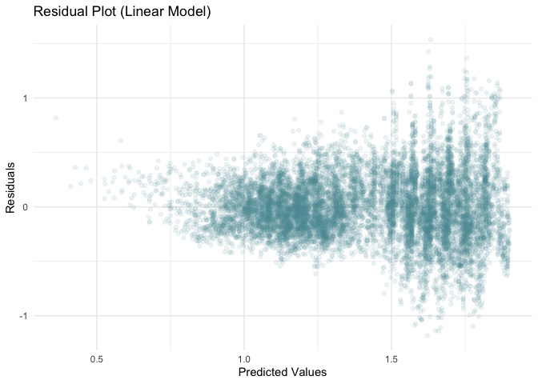

```r
model <- lm(average_price ~ total_volume + PLU_4046 + PLU_4225 + PLU_4770 + total_bags + small_bags + large_bags + xlarge_bags + type + year + lat + lon + season, data = avocado)

ggplot(model, aes(x = model$fitted.values, y = model$residuals)) +
  geom_point(colour= "cadetblue", alpha=0.1) +
  labs(title = 'Residual Plot (Linear Model)', x = "Predicted Values", y = "Residuals") +
  theme_minimal()
```

At a significance level of 0.05, it appears from the model below that the following features are significant as their p-values are less than the significance level:

- `type`
- `year`
- `lat`
- `lon`
- `season`
- `total_volume`
- `PLU_4046`
- `PLU_4225`
- `PLU_4770`

```r
tidy(model)
```

```
## # A tibble: 16 x 5
##    term            estimate std.error statistic   p.value
##    <chr>              <dbl>     <dbl>     <dbl>     <dbl>
##  1 (Intercept)  -127.       5.84        -21.7   1.91e-102
##  2 total_volume   -0.000170 0.0000632    -2.68  7.31e-  3
##  3 PLU_4046        0.000169 0.0000632     2.68  7.38e-  3
##  4 PLU_4225        0.000170 0.0000632     2.69  7.23e-  3
##  5 PLU_4770        0.000169 0.0000632     2.68  7.46e-  3
##  6 total_bags     -0.0304   0.0404       -0.754 4.51e-  1
##  7 small_bags      0.0306   0.0404        0.758 4.49e-  1
##  8 large_bags      0.0306   0.0404        0.758 4.49e-  1
##  9 xlarge_bags     0.0306   0.0404        0.758 4.49e-  1
## 10 typeorganic     0.465    0.00582      79.9   0.
## 11 year            0.0634   0.00290      21.9   2.01e-104
## 12 lat             0.00452  0.000544      8.31  1.04e- 16
## 13 lon             0.00117  0.000165      7.07  1.66e- 12
## 14 seasonSpring   -0.187    0.00737     -25.4   5.14e-139
## 15 seasonSummer   -0.0691   0.00761      -9.08  1.20e- 19
## 16 seasonWinter   -0.252    0.00734     -34.3   2.59e-246
```

However, we should be cautious not to use the p-value significance as a stand alone measure to determine if these features are correlated with the target. We will also conduct a multicollinearity test to determine if any of the features are redundant. We will then use these results to serve as a validation for our final feature importances model.